# Tooling ourselves up

1. Basics of document creation using Quarto

Pierre Walthéry

UK Data Service

3 June 2024

## Plan

- Three presentations:
  1. Basic of document creation with Quarto
  2. Using Git and GitHub for version control
  3. Online collaboration with GitHub
- Today:
  1. What is Quarto
  2. Structure and basic components
  3. A simple example
  4. More complex documents

# 1. What is Quarto?

## In a nutshell

- Open-source scientific and technical publishing system
- Developed by [Posit](https://posit.co/) (< [RStudio](https://posit.co/download/rstudio-desktop/) and [Tidyverse](https://www.tidyverse.org/))
- Next generation of Markdown, based on [Pandoc](https://pandoc.org/)
- At the core a bare-bones, text-based **markup language**.
- A markup language is a series of rules and conventions for designing documents and their components.
- Other examples of markup languages: html and LaTeX.
- Quarto is a standalone application; run either from an IDE (RStudio) or as a Command Line Interface (cli) in a terminal

## Features

- Produces documents in a multitude of formats (27):
  - Traditional (ie printable): pdf, html, .docx/odt, .ppt
  - Digital documents: ePub, MediaWiki
- Single files, complex documents ie books and websites
- Manages formulas, images, animations
- Run R, Python, Julia code and display output
- Shiny apps (still in progress)
- Facilitates reproducible research
- Time saving for documents that include code or code output

## How does it work?

- Typical workflow:
  1. Begins with creating a syntax file:
     - Text document with a .qmd extension
  2. Render (ie compile) the document
  3. Visualise the results
  4. Further edit/amend the document
  5. Render again…
  - RStudio provides quasi WYSIWIG document edition

# 2. Basic components of Quarto documents

## Basic structure

- Two main components:
  - Header
  - Main content
- Header
  - Denoted by three hyphens
  - Specific language: YAML (YAML Ain’t Markup Language)
  - Consist of a number of standardised options, typically:
    - Title, author, date, and document output format
  - Options may be document-wide or ‘suboptions’

## Example: syntax of this presentation

```
---
title: "Basics of document creation using Quarto"
author: Pierre Walthéry
date: today
date-format: d MMMM YYYY
format:
   revealjs:
     institute: UK Data Service
---

## What is Quarto

- Open-source scientific and technical publishing system
- Developed by Posit, (< RStudio and Tidyverse)
- Originates in Markdown and R Markdown
- At the core is  a simplified, text-based **markup language**.
```

## Running R Code (1)

```r
x <- seq(-4, 4, length=100)
y <- dnorm(x)
plot(x,y, type = "l", lwd = 2, axes = FALSE, xlab = "", ylab = "")
axis(1, at = -3:3, labels = c("-3s", "-2s", "-1s", "mean", "1s", "2s", "3s"))
```

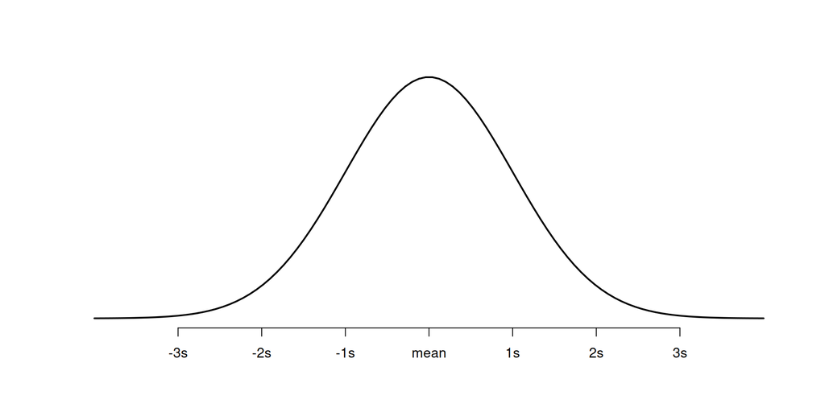

## The code can either be visible or not

The same plot with the R code hidden

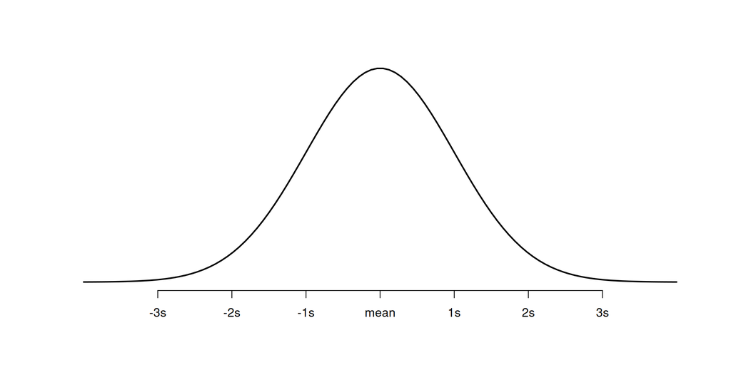

## Stata Code

```
Running /usr/local/stata16/profile.do . sysuse auto, clear
(1978 Automobile Data)

. describe

Contains data from /usr/local/stata16/ado/base/a/auto.dta
  obs:            74                          1978 Automobile Data
 vars:            12                          13 Apr 2018 17:45
                                              (_dta has notes)
-------------------------------------------------------------------------------
              storage   display    value
variable name   type    format     label      variable label
-------------------------------------------------------------------------------
make            str18   %-18s                 Make and Model
price           int     %8.0gc                Price
mpg             int     %8.0g                 Mileage (mpg)
rep78           int     %8.0g                 Repair Record 1978
headroom        float   %6.1f                 Headroom (in.)
trunk           int     %8.0g                 Trunk space (cu. ft.)
weight          int     %8.0gc                Weight (lbs.)
length          int     %8.0g                 Length (in.)
turn            int     %8.0g                 Turn Circle (ft.)
displacement    int     %8.0g                 Displacement (cu. in.)
gear_ratio      float   %6.2f                 Gear Ratio
foreign         byte    %8.0g      origin     Car type
-------------------------------------------------------------------------------
Sorted by: foreign
```

## Python code

```python
import numpy as np
import matplotlib.pyplot as plt
from scipy.stats import norm

#x-axis ranges from -3 and 3 with .001 steps
x = np.arange(-3, 3, 0.001)

#plot normal distribution with mean 0 and standard deviation 1
plt.plot(x, norm.pdf(x, 0, 1))
```

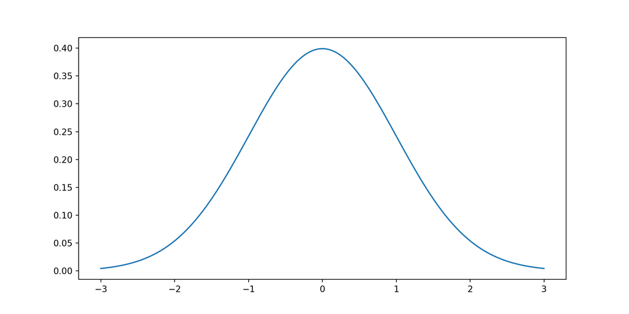

## RStudio and Quarto

- Full integration of Quarto within RStudio IDE
- Features:
  - Syntax highlighting
  - Python (< Jupyter), R(< knitR), Stata code chunks integration
  - Document rendering and visualisation
- Edited and run (almost) like any R syntax file

# 3. A simple example

## What we will do

- Create a Quarto document in RStudio
- Go through basic stylistic conventions
- Rendering in different formats
- Code chunks

[figure not shown]

# 4. More advanced aspects of document creation

## Additional topics for online documents

- Uniformising branding and formatting across documents
  - [Practical BSA material](https://github.com/UKDataServiceOpen/Introduction_to_the_BSA/blob/main/Population%20estimates%20using%20the%20BSAS%20with%20R.qmd)
- Creating complex documents (books and websites)
  - [R Guide](https://github.com/UKDataServiceOpen/UKDS_RGuide)

## Additional resources

- The [Quarto Website](https://quarto.org/docs/guide/) is a must for a comprehensive list of format specific options and capabilities.
- [2022 Get Started with Quarto workshop materials](https://rstudio-conf-2022.github.io/get-started-quarto/) (In-depth introduction to Quarto)
- For a general overview of Quarto capabilities, see [this presentation](https://rstudio-conf-2022.github.io/get-started-quarto/materials/01-intro-quarto.html#/so-what-is-quarto) in particular